# Study of Longley dataset

### 2) Is there a correlation between the GNP and the number of unemployed people?

[figure not shown]

```r
ggplot(longley, aes(x = Unemployed, y = GNP)) +
  geom_point(size = 4) +
  geom_smooth(method = "lm", formula = y ~ x, se = FALSE) +
  geom_text(x = 220, y = 550, label = "y = 0.35 * x + 290", color = "blue", size = 5) +
  ggtitle("Number of Unemployed people Vs the evolution of the GNP")
```

```r
mod <- lm(formula = GNP ~ Unemployed, data=longley)
summary(mod)
```

```
##
## Call:
## lm(formula = GNP ~ Unemployed, data = longley)
##
## Residuals:
##     Min      1Q  Median      3Q     Max
## -161.05  -55.10   27.59   57.20  114.90
##
## Coefficients:
##             Estimate Std. Error t value Pr(>|t|)
## (Intercept) 182.4558    75.1778   2.427   0.0293 *
## Unemployed    0.6427     0.2265   2.838   0.0132 *
## ---
## Signif. codes:  0 '***' 0.001 '**' 0.01 '*' 0.05 '.' 0.1 ' ' 1
##
## Residual standard error: 81.98 on 14 degrees of freedom
## Multiple R-squared:  0.3651, Adjusted R-squared:  0.3198
## F-statistic: 8.052 on 1 and 14 DF,  p-value: 0.01317
```

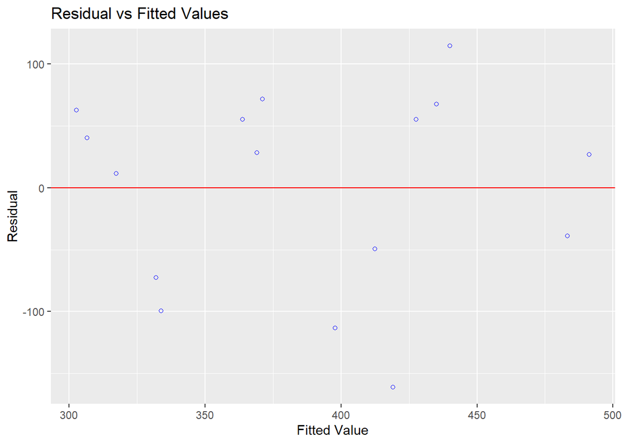

```r
model <- lm(GNP ~ Unemployed, data=longley)
ols_plot_resid_fit(model)
```

#### We can see the residual standard error is very high, above 80, meaning the model will not be very accurate. This is confirmed by the low value of r-squared.Therefore, we can not validate the hypothesis.

#### Because the hypothesis is not validate, we will not do some predictions.

### 3) Is there a correlation between the GNP and the number of people in the armed forces?

[figure not shown]

```r
ggplot(newDataFrame, aes(x = army, y = gnp)) +
  geom_point(size = 4) +
  labs(y = "GNP", x = "Armed.Forces") +
  geom_smooth(method = "lm", formula = y ~ x, se = FALSE) +
  geom_text(x = 500, y = 350, label = "y = -0.16 * x + 340", color = "blue", size = 5) +
  ggtitle("Number of people in the armed forces Vs the evolution of the GNP")
```

```r
mod <- lm(formula = gnp ~ army, data=newDataFrame)
summary(mod)
```

```
##
## Call:
## lm(formula = gnp ~ army, data = newDataFrame)
##
## Residuals:
##     Min      1Q  Median      3Q     Max
## -27.249 -15.017  -6.997  16.455  39.374
##
## Coefficients:
##              Estimate Std. Error t value Pr(>|t|)
## (Intercept) 473.77214   43.60041  10.866 7.39e-07 ***
## army         -0.41530    0.09995  -4.155  0.00196 **
## ---
## Signif. codes:  0 '***' 0.001 '**' 0.01 '*' 0.05 '.' 0.1 ' ' 1
##
## Residual standard error: 24.22 on 10 degrees of freedom
## Multiple R-squared:  0.6332, Adjusted R-squared:  0.5965
## F-statistic: 17.26 on 1 and 10 DF,  p-value: 0.001964
```

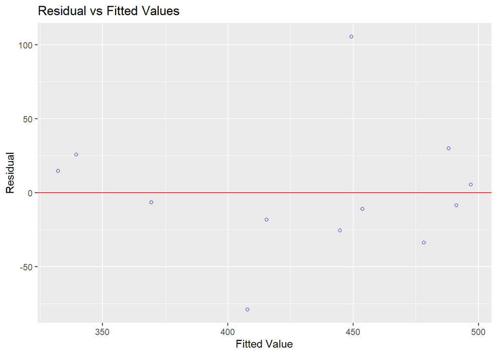

```r
model <- lm(army ~ gnp, data=newDataFrame)
ols_plot_resid_fit(model)
```

#### Because the hypothesis is not validate, we will not do some predictions.

### 4) Is there a correlation between the number of people in the armed forces and the ones undocumented?

[figure not shown]

```r
ggplot(newDataFrame, aes(x = army, y = population)) +
  geom_point(size = 4) +
  labs(y = "Population", x = "Armed.Forces") +
  geom_smooth(method = "lm", formula = y ~ x, se = FALSE) +
  geom_text(x = 500, y = 350, label = "y = -0.18 * x + 345", color = "blue", size = 5) +
  ggtitle("Number of people in the armed forces Vs the number of undocumented ones")
```

```r
mod <- lm(formula = army ~ population, data=newDataFrame)
summary(mod)
```

```
##
## Call:
## lm(formula = army ~ population, data = newDataFrame)
##
## Residuals:
##     Min      1Q  Median      3Q     Max
## -78.810 -19.945  -7.443  17.492 105.636
##
## Coefficients:
##             Estimate Std. Error t value Pr(>|t|)
## (Intercept)  880.295    109.065   8.071 1.09e-05 ***
## population    -1.525      0.367  -4.155  0.00196 **
## ---
## Signif. codes:  0 '***' 0.001 '**' 0.01 '*' 0.05 '.' 0.1 ' ' 1
##
## Residual standard error: 46.41 on 10 degrees of freedom
## Multiple R-squared:  0.6332, Adjusted R-squared:  0.5965
## F-statistic: 17.26 on 1 and 10 DF,  p-value: 0.001964
```

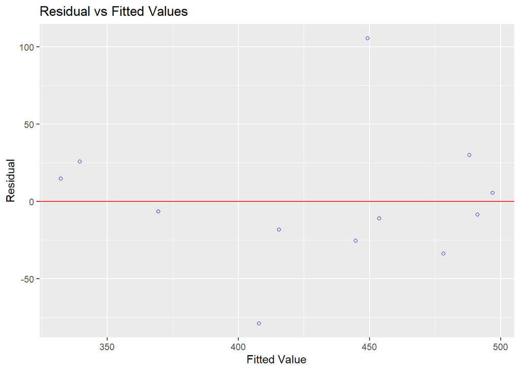

```r
model <- lm(army ~ population, data=newDataFrame)
ols_plot_resid_fit(model)
```

#### We can see the residual standard error is high, almost equals to 50, meaning the model will not be very accurate. However, the value of r-squared is equalled to 0.6, meaning the model is still a good one. Therefore, we can not validate the hypothesis.

#### Because the hypothesis is not validate, we will not do some predictions.

### 5) Is there a correlation between the number of unemployed people and the ones undocumented?

[figure not shown]

```r
ggplot(longley, aes(x = Unemployed, y = Population)) +
  geom_point(size = 4) +
  geom_smooth(method = "lm", formula = y ~ x, se = FALSE) +
  geom_text(x = 220, y = 130, label = "y = 0.035 * x + 110", color = "blue", size = 5) +
  ggtitle("Number of Unemployed people Vs number of undocumented people")
```

```r
mod <- lm(formula = Unemployed ~ Population, data=longley)
summary(mod)
```

```
##
## Call:
## lm(formula = Unemployed ~ Population, data = longley)
##
## Residuals:
##      Min       1Q   Median       3Q      Max
## -110.842  -50.308   -2.621   53.460  119.434
##
## Coefficients:
##             Estimate Std. Error t value Pr(>|t|)
## (Intercept) -763.665    307.033  -2.487  0.02610 *
## Population     9.223      2.610   3.533  0.00331 **
## ---
## Signif. codes:  0 '***' 0.001 '**' 0.01 '*' 0.05 '.' 0.1 ' ' 1
##
## Residual standard error: 70.33 on 14 degrees of freedom
## Multiple R-squared:  0.4714, Adjusted R-squared:  0.4336
## F-statistic: 12.48 on 1 and 14 DF,  p-value: 0.00331
```

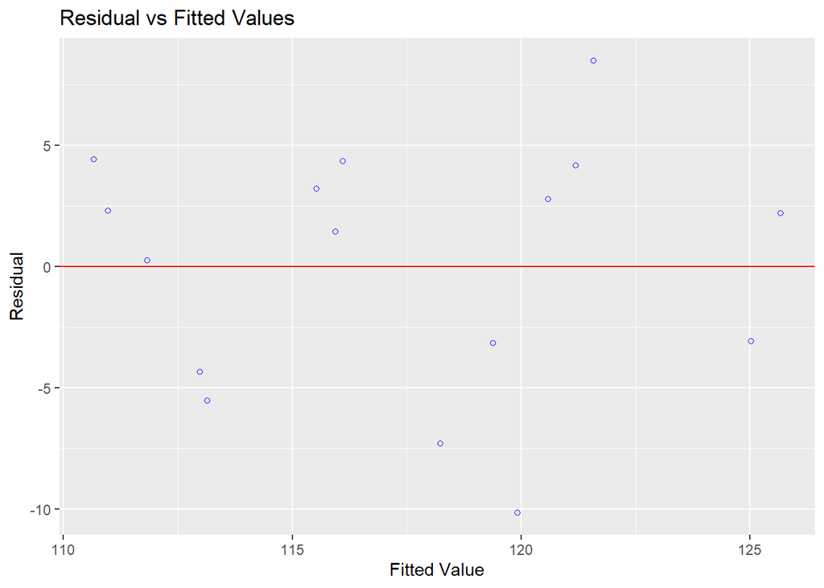

```r
model <- lm(Population ~ Unemployed, data=longley)
ols_plot_resid_fit(model)
```

#### We can see the residual standard error is high, with a value of 70, meaning the model will not be very accurate. Futhermore, the value of r-squared is below 0.5 by a little, meaning the model is still a good one but with a medium accuracy. Therefore, we can not validate the hypothesis.

#### Because the hypothesis is not validate, we will not do some predictions.

### 6) Is there a correlation between the number of undocumented people and the evolution of the GNP ?

[figure not shown]

```r
ggplot(longley, aes(x = Population, y = GNP)) +
  geom_point(size = 4) +
  geom_smooth(method = "lm", formula = y ~ x, se = FALSE) +
  geom_text(x = 110, y = 550, label = "y = 2.5* x + 235", color = "blue", size = 5) +
  ggtitle("Number of undocumented people people Vs the evolution of the GNP")
```

```r
mod <- lm(formula = GNP ~ Population, data=longley)
summary(mod)
```

```
##
## Call:
## lm(formula = GNP ~ Population, data = longley)
##
## Residuals:
##      Min       1Q   Median       3Q      Max
## -21.2942 -11.3519  -0.6804  11.2152  18.1277
##
## Coefficients:
##               Estimate Std. Error t value Pr(>|t|)
## (Intercept) -1275.2100    59.8256  -21.32 4.53e-12 ***
## Population     14.1616     0.5086   27.84 1.17e-13 ***
## ---
## Signif. codes:  0 '***' 0.001 '**' 0.01 '*' 0.05 '.' 0.1 ' ' 1
##
## Residual standard error: 13.7 on 14 degrees of freedom
## Multiple R-squared:  0.9823, Adjusted R-squared:  0.981
## F-statistic: 775.2 on 1 and 14 DF,  p-value: 1.168e-13
```

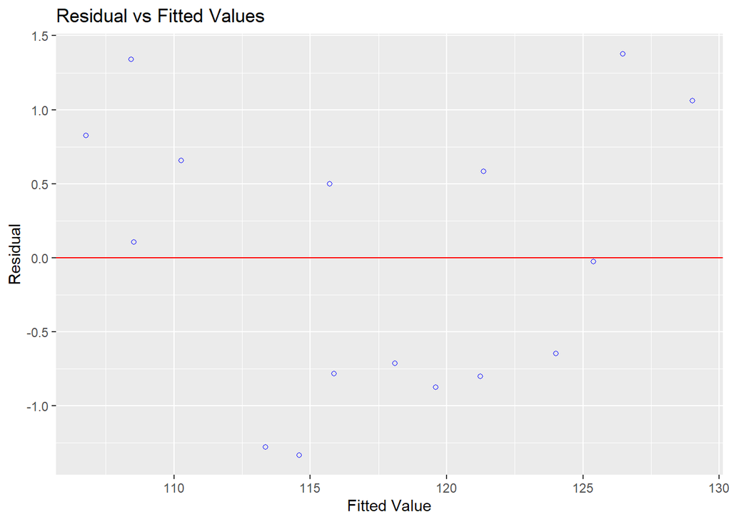

```r
model <- lm(Population ~ GNP, data=longley)
ols_plot_resid_fit(model)
```

#### We can see the residual standard error is low, below 15, meaning the model might be very accurate. Futhermore, the value of r-squared is above 0.9 and almost equalled to 1, meaning the model is almost a perfect one. Therefore, there is a very important correlation between the number of undocumented people and the evolution of the GNP and we can validate the hypothesis.

```r
2.5 * 135 + 235
```

```
## [1] 572.5
```

### 7) Is there a correlation between the GNP and the number of employed people?

[figure not shown]

```r
ggplot(longley, aes(x = Employed, y = GNP)) +
  geom_point(size = 4) +
  geom_smooth(method = "lm", formula = y ~ x, se = FALSE) +
  geom_text(x = 61.5, y = 550, label = "y = 4 * x + 235", color = "blue", size = 5) +
  ggtitle("Number of Employed people Vs the evolution of the GNP")
```

```r
mod <- lm(formula = GNP ~ Employed, data=longley)
summary(mod)
```

```
##
## Call:
## lm(formula = GNP ~ Employed, data = longley)
##
## Residuals:
##     Min      1Q  Median      3Q     Max
## -39.223 -11.920   0.855  14.882  23.555
##
## Coefficients:
##              Estimate Std. Error t value Pr(>|t|)
## (Intercept) -1430.482     89.361  -16.01 2.15e-10 ***
## Employed       27.836      1.366   20.37 8.36e-12 ***
## ---
## Signif. codes:  0 '***' 0.001 '**' 0.01 '*' 0.05 '.' 0.1 ' ' 1
##
## Residual standard error: 18.58 on 14 degrees of freedom
## Multiple R-squared:  0.9674, Adjusted R-squared:  0.965
## F-statistic: 415.1 on 1 and 14 DF,  p-value: 8.363e-12
```

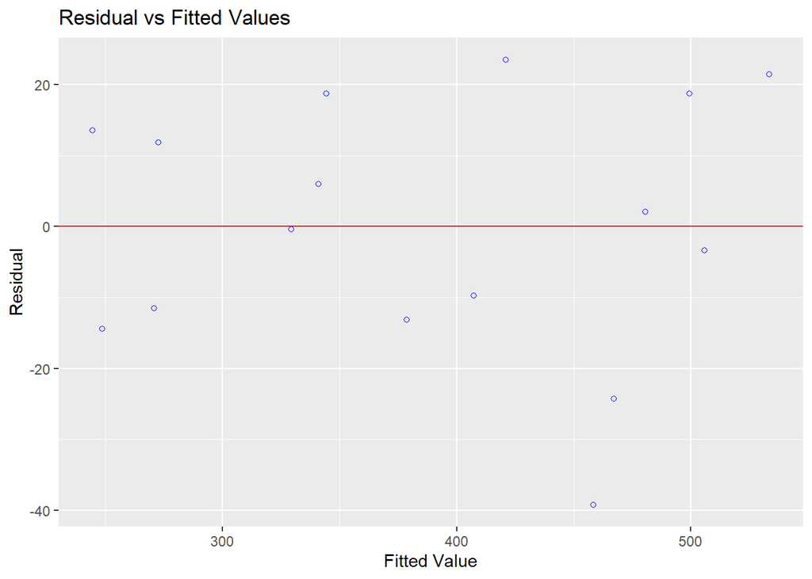

```r
model <- lm(GNP ~ Employed, data=longley)
ols_plot_resid_fit(model)
```

#### We can see the residual standard error is low, above 15 by little, meaning the model will be very accurate. Futhermore, the value of r-squared is above 0.9 and almost equalled to 1, meaning the model is almost a perfect one. Therefore, there is a very important correlation between the number of employed people and the evolution of the GNP and we can validate the hypothesis.

```r
4 * 80 + 235
```

```
## [1] 555
```

### 8) Is there a correlation between the number of employed and the number of unemployed people?

[figure not shown]

```r
ggplot(longley, aes(x = Employed, y = Unemployed)) +
  geom_point(size = 4) +
  geom_smooth(method = "lm", formula = y ~ x, se = FALSE) +
  geom_text(x = 61.5, y = 470, label = "y = 1.85 * x + 245", color = "blue", size = 5) +
  ggtitle("Number of Employed people Vs the number of Unemployed people")
```

```r
mod <- lm(formula = Employed ~ Unemployed, data=longley)
summary(mod)
```

```
##
## Call:
## lm(formula = Employed ~ Unemployed, data = longley)
##
## Residuals:
##     Min      1Q  Median      3Q     Max
## -6.0689 -2.3507  0.8362  2.3418  3.6973
##
## Coefficients:
##              Estimate Std. Error t value Pr(>|t|)
## (Intercept) 59.286355   2.882293  20.569 7.35e-12 ***
## Unemployed   0.018885   0.008684   2.175   0.0473 *
## ---
## Signif. codes:  0 '***' 0.001 '**' 0.01 '*' 0.05 '.' 0.1 ' ' 1
##
## Residual standard error: 3.143 on 14 degrees of freedom
## Multiple R-squared:  0.2525, Adjusted R-squared:  0.1991
## F-statistic: 4.729 on 1 and 14 DF,  p-value: 0.04729
```

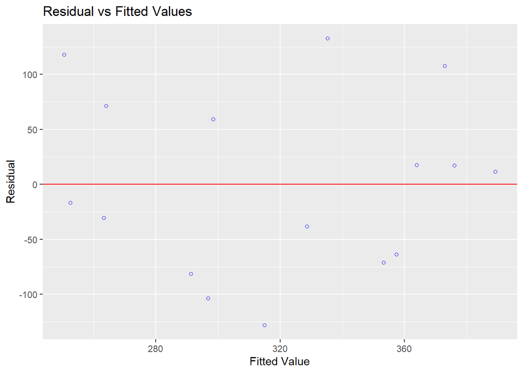

```r
model <- lm(Unemployed ~ Employed, data=longley)
ols_plot_resid_fit(model)
```

#### We can see the residual standard error is low, equalled to 3, meaning the model will be equally reparted from each side of the adjusted line. However, the value of r-squared is around 0.2, meaning the model is really not a good one. Therefore, we can not validate the hypothesis.

#### Because we can not validate the hypothesis, we will not try to do predictions.

# Conclusion

#### We also saw that wars cost a lot of money, meaning the GNP will not increase as much as it could, and can decrease. If the GNP decrease, the lifestyle of all the people will changed, and not in a good way. Plus, people returning from war are generally handicapped or have traumas. These persons may not be in the capacity to work, physically or mentally, for the rest of their life. Therefore, they will be put in the “Unemployed” case, or may be put in the “Undocumented” case, because they will not have enough money to keep their rights and properties.